# 2.- Setup

## 2.2 The Planetary System object

Once we have defined our planets, we can construct a Planetary System simply defining a system name, and stellar mass and radius (in Msun and Rsun units)

```python
# Let's call our system: "SystemX"
PS = nau.PlanetarySystem("SystemX", mstar=0.9132, rstar=0.8632)
```

Okay, but it is not a planetary systems if there are not planets! So, let's add the Planet objects created before by passing a list with the Planet objects inside:

```python
# The ordering is important!! It's more intuitive if you add them according to the proximity to the star
PS.add_planets([Planetb, Planetc])
```

```
--> Upper mass boundary for planet -Planet-b- has been set to 1.0% of stellar mass: 3040.4635872919343 [Mearth]
--> Parameter -ecc- of planet -Planet-c- set to lower physical limit: 1e-06
```

Alright! Now we have a Planetary System that looks like:

```python
print(PS)  # print a summary of the Planetary System
```

[output not shown]

That's it! We have a Planetary System!

Now, an extra feature: Nauyaca contains a built-in function to visualize the TTVs of our planets. Let's call the Plots module and pass the Planetary System and then plot the observed TTVs:

```
---> No data to plot
```

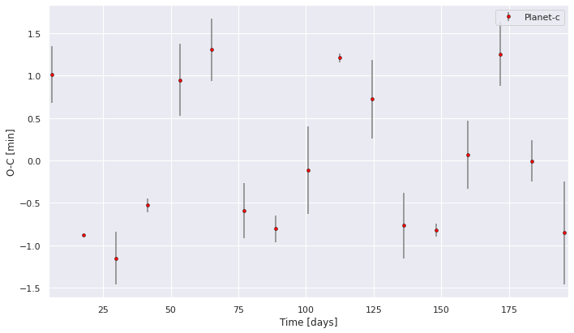

```python
nauplot = nau.Plots_c(PS, size=(10,6))  # Call the module specifying figure size

# Plot TTVs!
nauplot.plot_TTVs(residuals=False) # Don't make space for residuals
```

Cool, isn't?

## 2.3 Preparing for simulations

From the summary of our Planetary System, we see at the bottom part the simulation attributes that Nauyaca automatically calculates based on the provided information of the planets. These attributes are:

- **T0JD:** It is the reference time at which all the solutions found by Nauyaca will be referenced. By default, this number is automatically calculated by rounding down the smaller transit time found in the planet ephemerids.
- **Ftime:** It defines the maximum time of the simulations. By default, it is calculated automatically by rounding up the greater central time found in the planet ephemerids. If you define a lower value than the calculated by default, then, all the central transit times greater than this new number will be discarted (for all the planets) and the fitting will be performed until this new final time.
- **dt:** This is the timestep of the simulations. By default, it is calculated by dividing the period of the inner planet over 30, which represent the 3.33% of the orbital period of the inner planet. Note that a timestep lower than 5% of period corresponding to the internal planet is suggested to reach a good accuracy in the simulations

Let's see these attributes automatically calculated in our system:

```python
print(f"T0JD: {PS.T0JD}  [days]")
print(f"Ftime: {PS.Ftime}  [days]")
print(f"dt: {PS.dt}  [days]")
```

```
T0JD: 1.0  [days]
Ftime: 196.0  [days]
dt: 0.17847710000000017  [days]
```

For the purposes of this tutorial, let's change these parameters and let's see again the updated attributes in the planetary system

```python
# Setting the simulation attributes
PS.simulation(T0JD=0.0, Ftime=200, dt=0.15)

print(PS)
```

```
 =========== Planetary System Summary ===========
--> Parameter -ecc- of planet -Planet-b- set to lower physical limit: 1e-06
--> Parameter -ecc- of planet -Planet-c- set to lower physical limit: 1e-06

System: SystemX
Mstar: 0.9132 Msun |  Rstar: 0.8632 Rsun
Number of planets: 2
Planet information:
------
Planet: Planet-b
  Boundaries:
    mass: (1, 20.0)  [M_earth]
    period: (5.35, 5.36)  [d]
    ecc: (1e-06, 0.2)
    inclination: (85, 95)  [deg]
    argument: (0.0, 360)  [deg]
    mean_anomaly: (0.0, 360)  [deg]
    ascending_node: (88.36, 88.36)  [deg]
  TTVs: True
------
Planet: Planet-c
  Boundaries:
    mass: (1, 100)  [M_earth]
    period: (11.83, 11.84)  [d]
    ecc: (1e-06, 0.2)
    inclination: (85, 95)  [deg]
    argument: (0.0, 360)  [deg]
    mean_anomaly: (0.0, 360)  [deg]
    ascending_node: (0.0, 180.0)  [deg]
  TTVs: True

Simulation attributes:
Reference epoch of the solutions (T0JD): 0.0 [JD]
Total time of TTVs data (Ftime): 200 [days]
Timestep of the simulations (dt): 0.15 [days]
```

Nice! It appears that it is all ready to begin the simulations. But before, a **very important** step...